# Shark Fin Volume Analysis Report

Emma Mitchell

2025-01-07

## [GitHub Repository](https://github.com/emmaamitchyy/biol432)

### Introduction

This report analyzes shark fin measurement data, including fin width and length, and estimates the fin volume for various shark species using R. The shark species include Great White Sharks, Bull Sharks, Whale Sharks, Black tip Sharks, and Galapagos Sharks. The data is processed, analyzed and visualized using various R scripts. The goal of this report is to gain insights into fin volumes across shark species.

### Data Generation:

Load the Needed Packages:

```r
library(dplyr)
library(tidyverse)
```

```r
library(ggplot2)
```

```r
library(tidyr)
```

Before running the analysis, the data is generated using the ‘data_generator.R’ script. This script creates the ‘measurement.csv’ file, which contains data about shark species and fin measurements. This data set is then used to estimate fin volumes and perform further analysis

```r
source('datagenerato.R')
```

The generated data is then used to estimate the volume of various shark species fins. This value is then used to perform further analysis and compare fins across the five species measured.

```r
source('volumeEstimato.R')
```

In order to run analyses, open the measurement data generated from the volume estimator scrip:

```r
data<-read.csv("measurements.csv")
```

```r
head(data)
```

```
##          Species  Fin_Width Limb_Length Observer       Volume
## 1    whale_shark  0.1107716    178.3582   Olivia    0.5729528
## 2    whale_shark  1.2795166    179.4478   Olivia   76.9127921
## 3     bull_shark  4.5308327    204.6311   Olivia 1099.7557579
## 4     bull_shark  6.6261812    126.9494 Meredith 1459.2376975
## 5    whale_shark 17.9230591    117.8107      Ben 9907.8099131
## 6 blacktip_shark  0.3644350    128.5974      Ben    4.4713723
```

### Data Analysis:

To ensure clarity and organization in the data set, the data is sorted by species, observer, and then limb volume. This sorting allows us to easily group and compare measurements within each species and observer combination, while also identifying trends or outliers in limb volume. Organizing the data in this manner provides a structured foundation for further analysis and visualization.

```r
sorted_data <- data %>% arrange(Species, Observer, Volume)
```

```r
head(sorted_data)
```

```
##          Species Fin_Width Limb_Length Observer       Volume
## 1 blacktip_shark  0.364435   128.59737      Ben     4.471372
## 2 blacktip_shark 10.359171    78.71772      Ben  2211.521092
## 3 blacktip_shark 13.538955   110.41288      Ben  5298.569416
## 4 blacktip_shark 10.676751   258.32673      Ben  7709.322801
## 5 blacktip_shark 16.849306   143.56846      Ben 10670.670851
## 6 blacktip_shark 18.482903   136.34827      Ben 12194.349591
```

```r
avg_vol <- sorted_data %>%
  group_by(Species) %>%
  summarise(Average_Volume = mean(Volume))

#display table:
avg_vol
```

```
## # A tibble: 5 × 2
##   Species           Average_Volume
##   <chr>                      <dbl>
## 1 blacktip_shark             4723.
## 2 bull_shark                 5582.
## 3 galapagos_shark            4286.
## 4 great_white_shark          5524.
## 5 whale_shark                5506.
```

The table below illustrates the number of observations recorded for each shark species by different observers. This data helps to provide a clearer picture of how often each species is encountered and studied, reflecting both the frequency of sightings and the efforts of individual observers.

```r
# Calculate the number of observations for each species-observer combination:

obs_count <- sorted_data %>%
  group_by(Species, Observer) %>%
  summarise(num_observations = n())
#display the table of observations:
obs_count
```

```
## # A tibble: 15 × 3
## # Groups:   Species [5]
##    Species           Observer num_observations
##    <chr>             <chr>               <int>
##  1 blacktip_shark    Ben                     7
##  2 blacktip_shark    Meredith                3
##  3 blacktip_shark    Olivia                  9
##  4 bull_shark        Ben                     8
##  5 bull_shark        Meredith                6
##  6 bull_shark        Olivia                  6
##  7 galapagos_shark   Ben                     2
##  8 galapagos_shark   Meredith                5
##  9 galapagos_shark   Olivia                 10
## 10 great_white_shark Ben                     9
## 11 great_white_shark Meredith                4
## 12 great_white_shark Olivia                  8
## 13 whale_shark       Ben                     9
## 14 whale_shark       Meredith                5
## 15 whale_shark       Olivia                  9
```

### Results:

The following box plot is important for visualizing the distribution of fin volumes across different shark species. This plot highlights the variation in fin sizes, showing the median, quartiles, and potential outliers for each species. It provides a clear comparison of fin volume distributions, helping to illustrate the differences in size between species such as the Great White Shark, Bull Shark, Whale Shark, Galapagos Shark, and Black tip Shark.

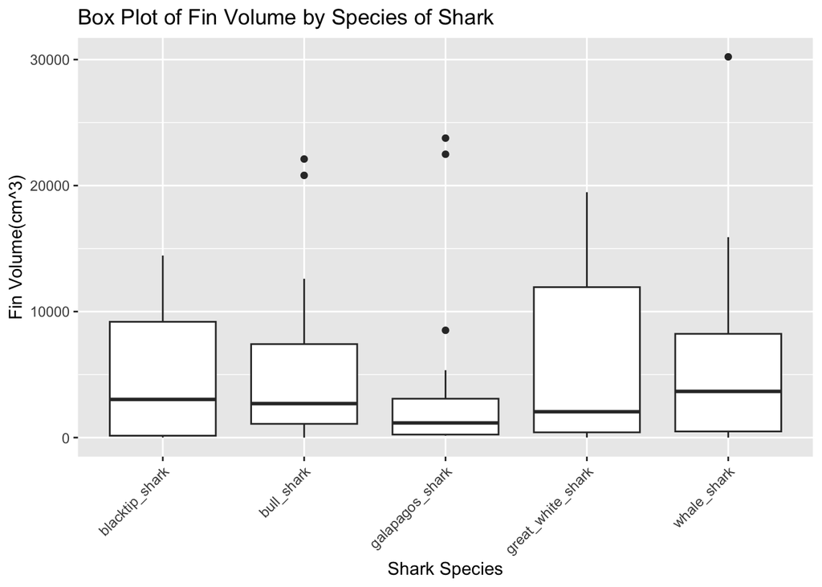

```r
#box plot to compare the distributions of fin volumes for each species of shark:
ggplot(sorted_data, aes(x=Species, y=Volume))+
  geom_boxplot()+
  labs(title = "Box Plot of Fin Volume by Species of Shark",
       x = "Shark Species", y = "Fin Volume(cm^3)")+
  theme(axis.text.x = element_text(angle = 45, hjust = 1))
```

**Figure 1. Box plot of fin volumes by shark species***.*

This plot displays the distribution of fin volumes for five shark species: Great White Shark, Bull Shark, Whale Shark, Galapagos Shark, and Black tip Shark. The boxes represent the interquartile range (IQR), with the median indicated by the line inside the box. Outliers are marked as individual points, providing insights into the variation in fin size within each species

A multi-panel plot was created to display the frequency histograms showing the distribution of limb volumes for each shark species. This visualization provides an effective way to compare the variations in limb volumes across different species. To facilitate the creation of this plot, the data was first transformed from a wide to a long format using appropriate R code. This allowed for easier plotting of the data by species. Each panel in the plot corresponds to a different species, and the histograms illustrate the frequency distribution of limb volumes within each species. This approach helps in understanding the differences and patterns in limb volume across the species in the study.

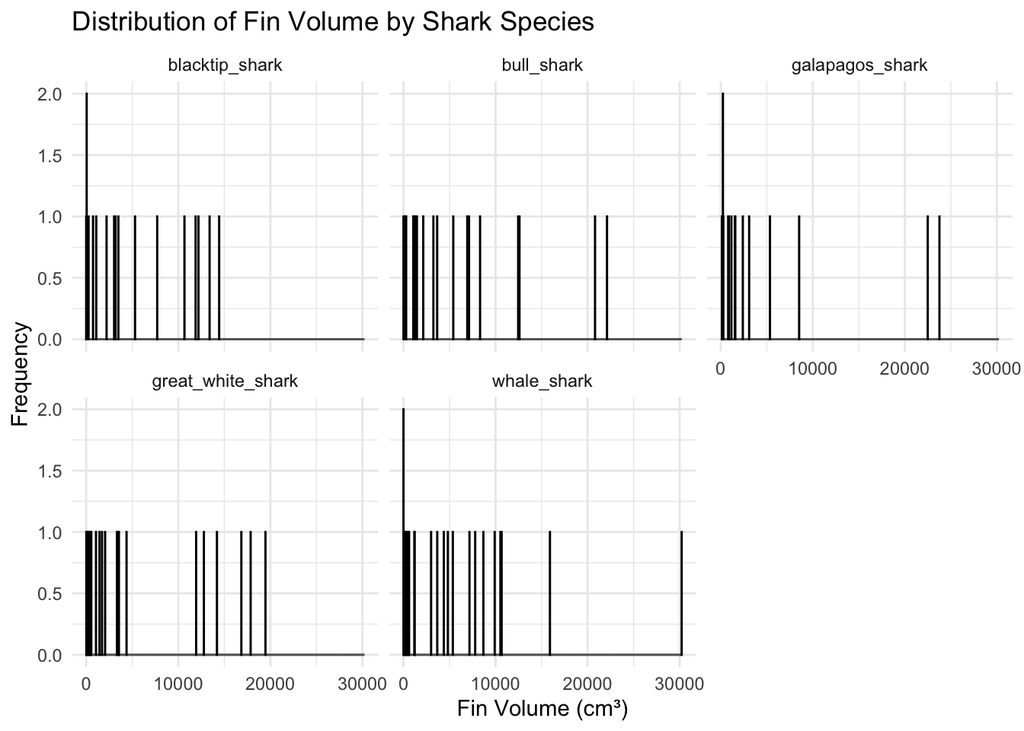

```r
# Convert the data to long format
shark_data_long <- sorted_data %>%
  pivot_longer(cols = Volume, names_to = "Measurement", values_to = "Value")

# Create a multi-panel histogram of fin volume distributions for each species
ggplot(shark_data_long, aes(x = Value)) +
  geom_histogram(binwidth = 10, fill = "blue", color = "black") +
  facet_wrap(~Species) +
  theme_minimal() +
  labs(title = "Distribution of Fin Volume by Shark Species", x = "Fin Volume (cm³)", y = "Frequency")
```

**Figure 2. Distribution of fin volume by shark species***.*

This multi-panel histogram shows the frequency distribution of fin volumes (in cm³) for each shark species. The data was converted from wide to long format using the pivot_longer function, with the fin volume measurements labeled as “Value” and grouped by species. Each panel represents a different species of shark, and the bin width for the histograms is set to 10 cm³. The plot highlights the variation in fin volume across shark species, with each species’ distribution displayed separately for comparison.